# statistics

*03_central_limit_theorem/03_central_limit_theorem/01_calculate_z_from_sample_mean_v4*

This question provides $\mu$, $\sigma$, $n$, and $\bar{x}$. You will characterize the sampling distribution, calculate the standard score, determine the percentile rank (expressed as a decimal), and translate the score into a rating (see below).

### Population

When Archie practices archery, each arrow has the same probability distribution (see [i.i.d](https://en.wikipedia.org/wiki/Independent_and_identically_distributed_random_variables)). This means her skill is constant, there is no [hot-hand effect](https://en.wikipedia.org/wiki/Hot_hand), and there is no [maturity of chances](https://en.wikipedia.org/wiki/Gambler%27s_fallacy).

Over many months, Archie has shot ten thousand arrows (their positions are shown below as dots).

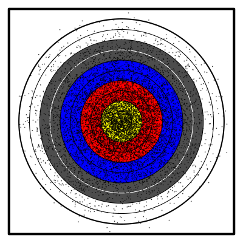

From those many arrows, Archie has determined an accurate probability distribution (of the points scored by an arrow).

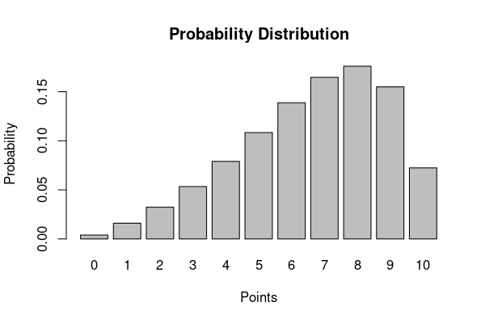

Thus, Archie can determine her population mean and population standard deviation.
$$\mu=6.61$$
$$\sigma=2.24$$

## Sampling distribution

Each day, Archie shoots 60 arrows ($n=60$) and determines that day’s mean score. A mean of 10 would be a perfect day. We can treat each day’s mean as a random variable with its own probability distribution: a [sampling distribution](https://en.wikipedia.org/wiki/Sampling_distribution). We wish to characterize this sampling distribution. From the [central limit theorem](https://en.wikipedia.org/wiki/Central_limit_theorem), we know the sampling distribution is approximately normal; however, we need to calculate the parameters.

### Expected mean (mean of sampling distribution)

The expected mean is simply the population mean.
$$\text{expected mean} = \mu$$

“Expected mean” is a misnomer. It is not necessarily likely, or even possible, for a mean to equal the expected mean. However, if Archie repeatedly shot 60 arrows, we expect the means to have a average equal to the expected mean. So, maybe “average of means” would be better terminology.

This expected mean is the average of the sampling distribution.

Determine the expected mean:

(Round to the hundredths place)

### Standard error (standard deviation of sampling distribution)

The standard error of a mean is the quotient of the population standard deviation and the square root of the sample size.
$$\text{standard error of mean} = \frac{\sigma}{\sqrt{n}}$$
This standard error is the standard deviation of the sampling distribution.

Calculate the standard error:

(Round to the thousandths place)

### Sample

Today, Archie’s mean score is 6.383 points ($\bar{x} = 6.383$).

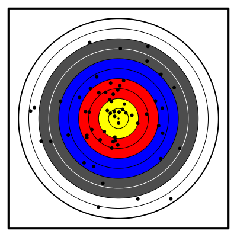

### Standard score

Archie would like to know how well she did today. She wants you to calculate a standard score (a $z$ score). To calculate the standard score of a sample mean, you can use the following formula.
$$z = \frac{\bar x - \mu}{\sigma/\sqrt{n}}$$

Calculate the standard score:

(Round to the hundredths place)

### Cumulative probability (percentile rank)

Archie would like to know the probability that tomorrow she shoots worse than today. To estimate this, report the cumulative probability associated with the $z$-score you calculated. This can be done with a [$z$ table](https://en.wikipedia.org/wiki/Standard_normal_table#Conversion), `pnorm` function in R, `NORM.DIST` function in a spreadsheet, or with other standard normal tools.

Calculate $P(Z\leq z)$, the cumulative probability:

(Round to the ten-thousandths place)

### Rating

Archie would like a rating for her day’s performance. You decide to use the following scale and that if $z$ is on a boundary, Archie will be given the higher rating.

| $z$ interval | rating |
| --- | --- |
| $-\infty$ to -1.51 | F |
| -1.5 to -0.51 | D |
| -0.5 to 0.49 | C |
| 0.5 to 1.49 | B |
| 1.5 to $\infty$ | A |

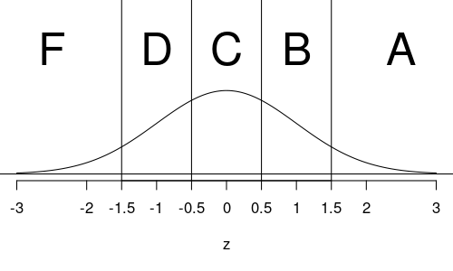

Determine Archie’s rating:

A / B / C / D / F